# AIRFLOW-DATA PIPELINE

LEANDER

17/01/2021

[figure not shown]

#### Apache Airflow is an open-source workflow management platform. It started at Airbnb in October as a solution to manage the company’s increasingly complex workflows. Creating Airflow allowed Airbnb to programmatically author and schedule their workflows and monitor them via the built-in Airflow user interface.

#### Airflow uses directed acyclic graphs (DAGs) to manage workflow orchestration. Tasks and dependencies are defined in Python and then Airflow manages the scheduling and execution. DAGs can be run either on a defined schedule (e.g. hourly or daily) or based on external event triggers .

## **STAGE-1 :DATA GATHERING**

#### The data has been gathered from FINNHUB.IO,an online financial instrument API that provides data on various american listed companies.

> I have gathered data relating to the public sentiment based on news media for leading companies in the tech sector including GOOGLE,MICROSOFT,ALIBABA,FACEBOOK etc.

## **STAGE-2 :DATA TRANSFORMATION**

> The final dataframe looks like so:

[figure not shown]

## **STAGE-3 :PIPELINE MONITORING**

#### Send an email once stage 2 has been completed.We can also monitor the pipeline through airflows inbuilt user interface.

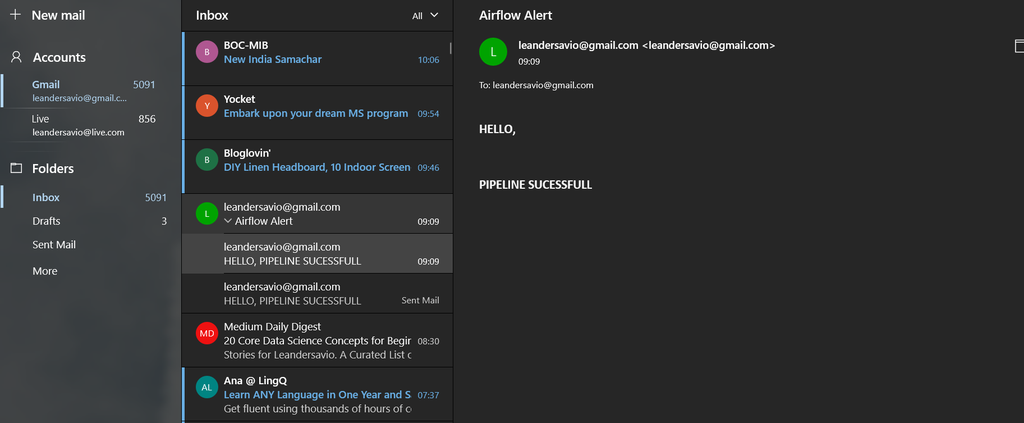

[figure not shown]

[figure not shown]

```python
from airflow import DAG
from airflow.operators import BashOperator
from airflow.operators.python_operator import PythonOperator
from datetime import datetime, timedelta
import requests
import pandas as pd
import json
from pandas.io.json import json_normalize
from airflow.operators.email_operator import EmailOperator

data_json=[]

default_args = {
    'owner': 'leander',
    'depends_on_past': False,
    'start_date': datetime.today() - timedelta(days=13),
    'email': ['leandersavio@gmail.com'],
    'email_on_failure': False,
    'email_on_retry': False,
    'retries': 1,
    'retry_delay': timedelta(seconds=10),
}

dag = DAG('MYDAG', default_args=default_args,schedule_interval='0 11 * * *')

def fetchDataAPI():
    symbols=['NFLX','MSFT','GOOGL','FB','AMZN','BABA','TSLA']

    for val in symbols:
        r = requests.get('https://finnhub.io/api/v1/news-sentiment?symbol='+str(val)+'&token=bvv9c7f48v6r5v93tap0')
        data_json.append(r.json())
        df = json_normalize(data_json)
        df.to_csv("/usr/local/airflow/stocks.csv")



def datatransform():
    df=pd.read_csv("/usr/local/airflow/stocks.csv")
    df_cols=df.iloc[:,[1,3,5,6,2,7]]
    df_cols.columns=['NewsScore','Symbol','Buzz','WeekAvgBuzz','BearSentiment','BullSentiment']
    df_cols=df_cols[['Symbol','NewsScore','Buzz','WeekAvgBuzz','BearSentiment','BullSentiment']]
    df_final=df_cols.sort_values(by=['BullSentiment'],ascending=False).reset_index()



fetchDataAPI = PythonOperator(
        task_id="fetch_data_from_API",
        python_callable=fetchDataAPI,
        dag=dag
    )
datatransform = PythonOperator(
        task_id="datatransform",
        python_callable=datatransform,
        dag=dag
    )

send_email = EmailOperator(
        task_id='send_email',
        to='leandersavio@gmail.com',
        subject='Airflow Alert',
        html_content=""" <h3>HELLO,</h3><br><h3> PIPELINE SUCESSFULL</h3> """,
        dag=dag
)



fetchDataAPI >> datatransform >> send_email
```